# Government Tweets and Their Author's Political Alignment

*By Beckett Welles*

## The Intro:

Welcome to my final project for CMSC320: Intro to Data Science. This project will act as a tutorial and walk you through what I’m trying to accomplish, how I’m attempting to do it, and what my results are.

## The Goal:

**Hypothesis**: Using only the text of a government official's tweet, we will be able to predict better than guessing the political affiliation of the government official.

**Null Hypothesis**: Using only the text of a government official's tweet, we will not be able to predict better than guessing the political affiliation of the government official.

## The Data:

Before beginning any kind of analysis, it’s extremely important to understand the data we will be working with. I will primarily be using data from https://github.com/alexlitel/congresstweets. This page has around five years' worth of tweets from over 1,000 Twitter accounts that are associated with political figures. This database contains not only the tweet, but also the account it’s from, the timestamp, and some additional metadata. For the purposes of this model, we will exclusively be using the text of the tweets themselves for prediction purposes. What this database notably does not contain however, is the political alignment of the Twitter user. For this information, I used an additional dataset database from the same creator, which contains information about the Twitter accounts featured in the first dataset. This second dataset can be found here: https://github.com/alexlitel/congresstweets-automator/. When we combine these two datasets together, we are able to get a list of over 4 million tweets that have corresponding political alignments, on which we can train or model.

## Exploring the Data

This section will be for looking at interesting patterns or trends in the data, in order to better understand it. Most of the attributes in the data that I used for this section are calculated in the later section **"The Code"**. So if you're running this on your own, ensure that you've run through the main code first.

Below I created a set of word clouds, each representing the most popular hashtags used by each political party. The red corresponds to Republican, and the blue represents Democrat. This representation is kind of fun, but also gives insight into how this model functions. We can see that for the most used hashtags, there is very little overlap between the hashtags used by Democrats and Republicans. This will be a very helpful tool for differentiating the author's political alignment.

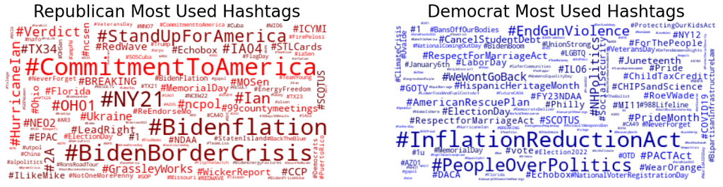

```python
def rand_red(word, font_size, position, orientation, random_state=None, **kwargs):
    return (random.randint(100, 255), 0, 0)
def rand_blue(word, font_size, position, orientation, random_state=None, **kwargs):
    return (0, 0, random.randint(100, 255))

cloud = WordCloud(background_color='white')
cloud.generate_from_frequencies(scored_set[scored_set['party']=='R']['hashtags'].explode().value_counts())

figure, axes = plt.subplots(1, 2, figsize=(20,20))
axes[0].imshow(cloud.recolor(color_func=rand_red),interpolation="bilinear")
axes[0].axis("off")
axes[0].set_title('Republican Most Used Hashtags', fontsize=26)


cloud = WordCloud(background_color='white')
cloud.generate_from_frequencies(scored_set[scored_set['party']=='D']['hashtags'].explode().value_counts())

axes[1].imshow(cloud.recolor(color_func=rand_blue),interpolation="bilinear")
axes[1].axis("off")
axes[1].set_title('Democrat Most Used Hashtags', fontsize=26)
plt.show()
```

I was curious to see the length of tweets, as I expected there would be a large spike at the character limit. We can see somewhat unexpectedly, that the lengths actually can be longer than the Twitter character limit. This is because of two reasons: retweets are included in the text, and so are urls to embedded images.

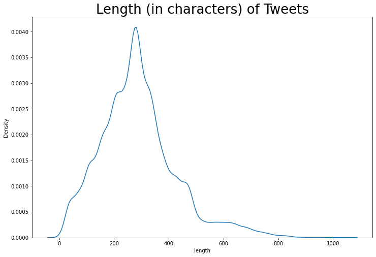

```python
import seaborn as sns
import matplotlib.pyplot as plt
unscored_set['length'] = scored_set['text'].str.len()
figure, axes = plt.subplots(1, 1, figsize=(12,8))
axes.set_title('Length (in characters) of Tweets', fontsize=26)
sns.kdeplot(data=unscored_set, x="length",  ax=axes)
```

Below we can see the top mentions and top domains used by each political party.

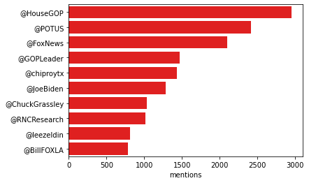

```python
r_mentions = unscored_set[unscored_set['party']=='R']['mentions'].explode().value_counts().head(10).to_frame()
sns.barplot(x="mentions", y=r_mentions.index, data=r_mentions, color="r")
```

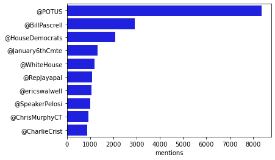

```python
d_mentions = unscored_set[unscored_set['party']=='D']['mentions'].explode().value_counts().head(10).to_frame()
sns.barplot(x="mentions", y=d_mentions.index, data=d_mentions, color="b")
```

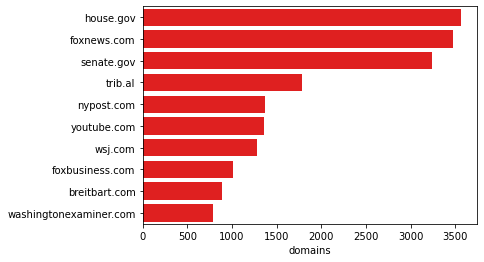

```python
r_domains = unscored_set[unscored_set['party']=='R']['domains'].explode().value_counts()[2:12].to_frame()
sns.barplot(x="domains", y=r_domains.index, data=r_domains, color="r")
```

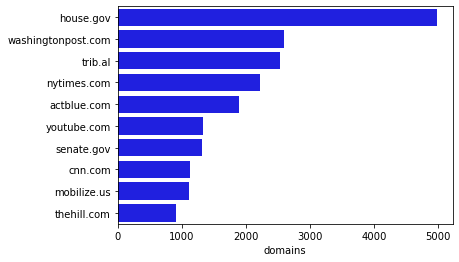

```python
d_domains = unscored_set[unscored_set['party']=='D']['domains'].explode().value_counts()[2:12].to_frame()
sns.barplot(x="domains", y=d_domains.index, data=d_domains, color="b")
```

## The Code

The code block below represents the beginning of creating our model. In this we begin by not only importing all the libraries and functions that we will need for our code to run, but we also define a helper method *print_percent*. This method is helpful as many of the operations contained within the model are slow, so a function like this one helps us see how different phases are progressing.

### load_and_preprocess()

After this, we have the function *load_and_preprocess*. As its name suggests, the purpose of this function is to load both of datasets into memory. Additionally, this method also combines them as I described above, so that each tweet in the tweet database is given a corresponding political alignment.

Databases can come in a lot of different forms. The database containing the tweets in this case came as a folder full of JSON files. So in cases like this we simply iterate through the files, loading them one at a time and combining them. For this model specifically, I added an adjustable limiter on the number of files that loads. This is because the model is too slow for me to reasonably train on the entire dataset, and to speed things up I only load about as much as I need.

```python
import re
from urllib.parse import urlparse
from textblob import TextBlob
import pandas as pd
import os
import math
from sklearn.feature_extraction.text import CountVectorizer
from sklearn.decomposition import LatentDirichletAllocation
from sklearn.model_selection import train_test_split
from sklearn.linear_model import LinearRegression
from sklearn.metrics import mean_squared_error, mean_absolute_error
from sklearn import preprocessing
from sklearn.metrics import accuracy_score
from sklearn.ensemble import RandomForestClassifier
from wordcloud import WordCloud
import matplotlib.pyplot as plt
import random


def print_percent(curr,total,gran,title):
    delta=gran*total
    if curr%delta<1:
        print (title+": {:.3f}".format(curr/total)+'\t\t\t', end="\r")

def load_and_preprocess(load_percent):
    userdata = pd.read_json("historical-users-filtered.json").explode('accounts').reset_index()
    for index,row in userdata.iterrows():
        userdata.loc[index,'user_id'] = row['accounts']['id']
        userdata.loc[index,'screen_name'] = row['accounts']['screen_name']
        userdata.loc[index,'account_type'] = row['accounts']['account_type']
    userdata['user_id'] = userdata['user_id'].astype('int64')

    data_path = "./data/"
    filenames = os.listdir(data_path)
    filenames = filenames[-int(len(filenames)*load_percent):]
    file_contents=[]
    df = pd.DataFrame()

    for index, filename in enumerate(filenames):
        print_percent(index, len(filenames), 0.001, 'Data Loading Progress')
        curr_file = pd.read_json(data_path+filename)
        file_contents.append(curr_file)

    df = pd.concat(file_contents, ignore_index=True)
    combined_df = pd.merge(df, userdata, on='user_id',how='left')
    combined_df['time'] = pd.to_datetime(combined_df['time'])

    return combined_df
```

## process()

Like any dataset, this one needs a lot of processing before it can be used in the model. This function is where we begin to extract the attributes that we will use to predict its political alignment.

The first attribute we pull out of the tweets is the sentiment score. Sentiment analysis is a form of natural language processing, where the model tries to evaluate the overall attitude/sentiment of the text. A very positive and happy seeming tweet would get a score of 1, while a negative and pessimistic tweet would get a score of -1. You can read more about it here: https://monkeylearn.com/sentiment-analysis/

Next, I pull out user mentions, hashtags, and URLs from the tweets. For each of these, I used regex, which is a helpful tool for pattern-matching text. In this specific case, as the regex for a URL is quite complicated I opted to use one from https://uibakery.io/regex-library/url-regex-python. This website and ones like it contain a lot of helpful regex statements for a variety of uses. Finally, I remove all of the things I just pulled out from the tweet, so we have a cleaner tweet to use for topic modeling.

```python
def process(df):
    for index, row in df.iterrows():
        print_percent(index, len(df.index), 0.001, 'Sentiment Score Progress')
        df.loc[index,"sentiment_score"] = TextBlob(str(row["text"])).sentiment.polarity

    df['mentions'] = df['text'].str.findall(re.compile('@\w+'))
    df['hashtags'] = df['text'].str.findall(re.compile('#\w+'))

    # Regex for URL was sourced from https://uibakery.io/regex-library/url-regex-python
    df['urls'] = df['text'].str.findall(re.compile("https?:\\/\\/(?:www\\.)?[-a-zA-Z0-9@:%._\\+~#=]{1,256}\\.[a-zA-Z0-9()]{1,6}\\b(?:[-a-zA-Z0-9()@:%_\\+.~#?&\\/=]*)"))
    df['urls'] = df["urls"].apply(lambda x: [urlparse(i) for i in x])

    df['domains'] = df["urls"].apply(lambda x: [i.netloc.split('.')[-2]+'.'+i.netloc.split('.')[-1] for i in x])
    df['clean_tweet'] = df['text'].str.replace(re.compile('(?:@\w+|#\w+|https?:\\/\\/(?:www\\.)?[-a-zA-Z0-9@:%._\\+~#=]{1,256}\\.[a-zA-Z0-9()]{1,6}\\b(?:[-a-zA-Z0-9()@:%_\\+.~#?&\\/=]*))'),'')

    return df
```

## gen_training_groups()

When training any kind of model, in order to see the effectiveness of the model it’s important to have distinct training sets and test sets. This function simply makes sure we have a set with an equal number of Republican and Democrat tweets, then splits it into the testing and training set. Because we equal number of each political party, we know that a random guess should only be correct 50% of the time, which will make it easy to see how our model performs compared to guessing.

```python
def gen_training_groups(df, training_size, test_ratio):
    party_size = int(training_size/2)

    dems = df[df['party']=='D'].sample(n=party_size, random_state=7744)
    reps = df[df['party']=='R'].sample(n=party_size, random_state=7744)

    training_small = pd.concat([dems, reps], ignore_index=True)

    X = training_small['text']
    y = training_small['party']

    return  train_test_split(X, y, test_size=test_ratio, random_state=7744)
```

## train_occurance_score() and score_occurance()

One of the main ways this model predicts political affiliation is by looking at user mentions, hashtags used, and externally linked websites. The purpose of **train_occurance_score()** to look at all of the different items and see how commonly used each item is by either political party. Items used by predominantly Democrats receive a positive score, and items used predominantly by Republicans receive a negative score. The magnitude of this score is determined by two factors. How often in total the item was used, and how strongly the item correlated to one of the parties. The weight calculated by the total usage was done using a logarithmic scale, so that very popular items wouldn’t completely outweigh less common ones.

Once a score is computed for each type of item this is where **score_occurance()** comes in. We give the tweets a political leaning score for each type of item. So for instance, a tweet will have a score for the political alignment of the websites it linked to. All of these scores will be directly fed into a classifier model later to be used for predictions.

```python
def train_occurance_score(df, col, blacklist):
    r_series = df[df['party']=='R'][col].explode().value_counts()
    r_series = r_series[r_series > 5]
    r_series = r_series.rename("r_occurances")

    d_series = df[df['party']=='D'][col].explode().value_counts()
    d_series = d_series[d_series > 5]
    d_series = d_series.rename("d_occurances")

    rd_combined = pd.concat([r_series,d_series],axis=1)
    rd_combined['r_occurances'] = rd_combined['r_occurances']*(d_series.size / r_series.size )
    rd_combined = rd_combined.fillna(0)

    rd_combined['total'] = rd_combined['r_occurances'] + rd_combined['d_occurances']
    rd_combined['log_total'] = rd_combined['total'].apply(lambda x: math.log(x))
    rd_combined['raw_score'] = rd_combined['d_occurances'] - rd_combined['r_occurances']
    rd_combined['score'] = (rd_combined['raw_score']/rd_combined['total'])*rd_combined['log_total']

    df = score_occurance(df, col, rd_combined['score'], blacklist)

    return df, rd_combined['score']


def score_occurance(df, col, item_scores, blacklist):
    df[col+'_score'] = 0
    for index, row in df.iterrows():
        print_percent(index, len(df.index), 0.001, col+' scoring progress')
        total = 0
        for x in row[col]:
            if (x in item_scores.index) and (x not in blacklist):
                total += item_scores.loc[x]
        df.loc[index,col+'_score'] = total
    return df
```

## lda_train() and lda_predict()

These two functions are another way that natural language processing finds its way into this project. Latent Dirichlet Allocation (or LDA) is a statistical method for identifying topics in a series of texts. It essentially sees which words are often used together and groups them into topics. Each word in the English language then has a score for how related to a topic it is. After LDA trains on a set of texts and establishes topics, it can then be used to find those topics in other texts. Out of all the other models used within this project, LDA is by far the most resource-intensive and therefore the slowest. You can read more about running LDA here: https://www.analyticsvidhya.com/blog/2021/06/part-2-topic-modeling-and-latent-dirichlet-allocation-lda-using-gensim-and-sklearn/.

```python
def lda_train(df):
    count_vector = CountVectorizer(max_df=0.8, min_df=2, stop_words='english')
    terms = count_vector.fit_transform(df['clean_tweet'].values.astype('U'))

    lda_component_num = 40
    lda_model = LatentDirichletAllocation(n_components=40, random_state=7744)
    lda_model.fit(terms)
    topic_values = lda_model.transform(terms)
    return lda_model, count_vector, topic_values

def lda_predict(df, lda_model, count_vector):
    topic_values = count_vector.transform(df['clean_tweet'].values.astype('U'))
    return lda_model.transform(topic_values)
```

Below is an example of the output of the LDA model. As we can see, these are 5 of the topics it identified. While LDA cannot actually name/identify the topic, it can identify which words are most commonly associated with a given topic. For each of the five topics, it's likely you're able to tell the general theme of each topic.

```python
for i,topic in enumerate(lda_model.components_[:5]):
    print('Topic #',i,'top words:')
    words = []
    for j in topic.argsort()[-10:]:
        words.append(count_vector.get_feature_names_out()[j])
    print(words,'\n')
```

```
Topic # 0 top words:
['abuse', 'held', 'congress', 'jim', 'fraud', 'qt', 'hold', 'rt', 'accountable', 'amp']

Topic # 1 top words:
['pact', 'deserve', 'toxic', 'rt', 'va', 'senate', 'care', 'benefits', 'act', 'veterans']

Topic # 2 top words:
['people', 'rt', 'hate', 'victims', 'today', 'lgbtq', 'shooting', 'families', 'community', 'amp']

Topic # 3 top words:
['roe', 'republicans', 'rt', 'protect', 'reproductive', 'ban', 'right', 'rights', 'women', 'abortion']

Topic # 4 top words:
['white', 'qt', 'don', 'president', 'house', 'democrats', 'people', 'rt', 'joe', 'biden']
```

## train()

This function is where everything comes together. It takes in the training data set and begins running it through all the previous processes that we’ve discussed. It processes and cleans the data, runs sentiment analysis, calculates scoring based on the occurrences of different items, and performs LDA topic modeling. Now that we have all of the different scores and metrics in one place, we can finally give them to our classifier.

For this project, I chose a Random Forest Classifier. Random Forest models essentially are made up of many decision trees that work together to make a single final prediction. You can read more about how this type of model functions here: https://towardsdatascience.com/understanding-random-forest-58381e0602d2. I originally used a variety of different classifiers including linear regression and SVM but found Random Forest produced the highest levels of accuracy. When we train a classifier, it essentially figures out which attributes to weigh more heavily than others, and in which direction each attribute influences the outcome, in this case, political alignment. Once it’s finished with this, we can then pass on all of the trained models, so that we can run predictions on the test data set and see the accuracy of this model.

```python
def train(X_train,y_train):
    df = pd.concat([X_train,y_train], ignore_index=True, axis=1)
    df = df.rename(columns={0: "text", 1: "party"})
    df = df.reset_index()

    print('Beginning processing...\t\t')
    df = process(df)

    print('Beginning occurance scoring...\t\t')
    df, mention_item_scores = train_occurance_score(df, 'mentions',[])
    df, domain_item_scores= train_occurance_score(df, 'domains',[])
    df, hastag_item_scores = train_occurance_score(df, 'hashtags',[])
    item_scores = {'mentions':mention_item_scores,'domains':domain_item_scores,'hashtags':hastag_item_scores}

    print('Beginning LDA model training ...\t\t')
    lda_model, count_vector, topic_values = lda_train(df)
    topic_values_df = pd.DataFrame(topic_values, columns = range(0,40))


    X_train_scores = df[['mentions_score','domains_score','hashtags_score']]
    X_train_scores = pd.concat([X_train_scores,topic_values_df], ignore_index=True, axis=1)

    print('Beginning classification model training ...\t\t')
    classification_model = RandomForestClassifier()
    classification_model.fit(X_train_scores, y_train)

    return df, classification_model, lda_model, count_vector, item_scores
```

## predict()

By the time this function is called, we have loaded all of our data, split it into testing/training groups, and run it through the training phase of our model. This function takes in all the trained models that have been produced and then uses them on data the model has yet to see. Unlike the training parts, this function is crucially not given the political alignment of the tweets and must guess for itself.

The function does get to do the same processing that has been done in the past, where user items are pulled out of the tweet and the tweet is cleaned. Then using each of the trained models that it has been passed, it runs the testing set through these models. This gives it a final array of values for each of the tweets. This matrix is then fed to the trained classifier, which for each tweet guesses the political alignment of the tweet’s author. The function then returns this list of predictions, which will be evaluated for accuracy.

```python
def predict(df, classification_model, lda_model, count_vector, item_scores):
    print('Beginning processing...\t\t')
    df = df.to_frame().reset_index()
    df = process(df)

    print('Beginning occurance scoring...\t\t')
    df = score_occurance(df, 'mentions', item_scores['mentions'], [])
    df = score_occurance(df, 'domains', item_scores['domains'], [])
    df = score_occurance(df, 'hashtags', item_scores['hashtags'], [])

    print('Beginning LDA predicting ...\t\t\t\t')
    topic_values = lda_predict(df, lda_model, count_vector)
    topic_values_df = pd.DataFrame(topic_values, columns = range(0,40))

    X_predict_scores = df[['mentions_score','domains_score','hashtags_score']]
    X_predict_scores = pd.concat([X_predict_scores,topic_values_df], ignore_index=True, axis=1)

    print('Beginning classification predicting ...\t\t')
    predictions = classification_model.predict(X_predict_scores)
    return predictions
```

## Results and Hypothesis Testing

```python
unscored_set = load_and_preprocess(0.1)
```

```
Data Loading Progress: 0.995
```

```python
X_train, X_test, y_train, y_test = gen_training_groups(unscored_set, 200000, 0.3)
```

```python
scored_set, classification_model, lda_model, count_vector, item_scores = train(X_train, y_train)
```

```
Beginning processing...
Beginning occurance scoring...
Beginning LDA model training ...
Beginning classification model training ...
```

```python
predictions = predict(X_test, classification_model, lda_model, count_vector, item_scores)
```

```
Beginning processing...
Beginning occurance scoring...
Beginning LDA predicting ...
Beginning classification predicting ...
```

```python
accuracy_score(y_test, predictions)
```

```
0.8344166666666667
```

## Results and Hypothesis Testing

So in the end I chose to train this model on 200,000 tweets. This process took about 10 minutes to load the datasets, train them, then test them. In the end, we achieved an accuracy score of around 83%. This is actually higher than I originally had anticipated, as when I manually tried to identify tweets I only achieved an accuracy of 75%, meaning that my model most likely is better than I am at predicting political alignment.

But what do these results mean for our hypothesis? In order for our hypothesis to be correct, we must disprove our null hypothesis. Commonly a p-value of less than 0.05 is needed to say that the null hypothesis is incorrect. A p-value indicates the probability that the current result was achieved given that the null hypothesis is true. So a p-value of 0.05 equates to a 1 in 20 chance that this result could have been obtained with a correct null hypothesis.

So how would we calculate the p-value in this case? Since the dataset we tested on has almost an identical number of Republican and Democratic tweets, we can clearly see that by guessing we would be correct 50% of the time. In this case, we can use a binomial probability calculator to find the p-value. We know out of 60,000 test tweets, we correctly guessed 50,065, so we can plug these in to find the p-value for our model.

```python
from scipy.stats import binomtest
successes=50065
number_of_trials=60000
probability_of_success=0.5
binom = binomtest(successes, number_of_trials, probability_of_success)
print(binom.pvalue)
```

```
0.0
```

As we can see, we get a p-value of 0. While in actuality it isn’t zero, it's so small that python just rounded it to a zero. This intuitively makes sense of course, as when we’re dealing with such large numbers the chance that we guessed so many correctly is incredibly small. Since our p-value is (very) below 0.05, we can conclude that the null hypothesis likely is incorrect. This means that our initial hypothesis is correct, and we were able to make a model that can guess the political alignment of the author better than random guessing.

So what can we do to improve? One of the easiest ways to improve the model accuracy is to increase the sample size. For this model in particular, I’ve noticed that increasing the sample size has consistently increased the accuracy of the model quite significantly. Additionally, there are many parameters in this model that could be tuned for better results. For instance, the number of topics the LDA model produces. There are also likely many more attributes to be considered that would increase the accuracy at least somewhat. However, there is a limit as to how far it can be increased, given that some tweets are so short or simply lack any kind of partisan content, so a model can only perform so well. Overall, I’m very happy with the accuracy of the model.

## Graphing the Results

Below we can see that with Democrats we were correct slightly more often, though both groups proved to be fairly similar in how often they were guessed correctly.

```python
correct = pd.concat([X_test,pd.Series(y_test)], axis=1).reset_index()
correct['prediction'] = pd.Series(predictions)
correct['correct'] = correct['prediction'] == correct['party']
correct['correct_int'] = correct['correct'].astype(int)
correct = pd.merge(correct,unscored_set, how='left', on='text')
correct['length'] = correct['text'].str.len()
```

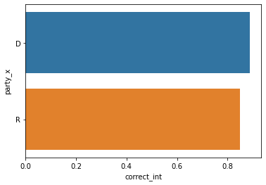

```python
party_score = correct.groupby('party_x').mean()['correct_int'].to_frame()
sns.barplot(x="correct_int", y=party_score.index, data=party_score)
```

## Try For Yourself!

You can run the below code to test if you're better than my model. Just respond with 'D' for Democrat, or 'R' for Republican to make your guess and see how you stack up.

```python
import random
from IPython.display import clear_output

correct = 0
wrong = 0
while True:
    rand_index = random.randint(0, len(scored_set.index))
    rand_tweet = scored_set.loc[rand_index,'text']
    rand_party = scored_set.loc[rand_index,'party']
    print('Tweet#:',correct+wrong)
    print('*'*20)
    print(rand_tweet)
    print('*'*20)
    inp = input('Party').upper()
    if inp == 'Q':
        break
    if str(rand_party) == inp:
        correct += 1
    else:
        wrong += 1
    print('Accuracy:',correct/(wrong+correct))
print('Correct:',correct)
print('Wrong:',wrong)
print('Accuracy:',correct/(wrong+correct))
```

```
Tweet#: 0
Today is #NationalAirborneDay. Yesterday American hero Tom Rice turned 101 years old. He was one of the first men to jump into Normandy ahead of D-Day. Love all vets, even the legs, but especially the airborne infantry. Hooah!
https://www.dday-overlord.com/en/battle-of-normandy/biographies/usa/thomas-m-rice
```

```
Accuracy: 1.0
Tweet#: 1
RT @RepKevinBrady The #BidenBorderCrisis is dangerous and inhumane—and it's only getting worse.

"Just in August, more than 25,000 Venezuelans were stopped crossing the U.S. border with Mexico with more than 18,000 of those coming between Del Rio and Eagle Pass."
https://www.houstonchronicle.com/politics/texas/article/Record-surge-of-Venezuelan-asylum-seekers-strain-17454392.php
```

```
Accuracy: 1.0
Tweet#: 2
RT @AdamLaxalt After traveling to every corner of Nevada on our #LeadWithLaxalt Bus Tour, I know how much Nevadans want change for our great state.

I can’t make that happen without you and your vote today.

Your voice matters. Nevada matters.

Let’s do this. http://pbs.twimg.com/ext_tw_video_thumb/1590072474380558337/pu/img/CfF8MLUNJt0_rf_H.jpg https://video.twimg.com/ext_tw_video/1590072474380558337/pu/vid/480x270/q6N528RpEg1YRVmV.mp4?tag=12
```

```
Correct: 2
Wrong: 0
Accuracy: 1.0
```